# Final Report

## Finalized Predictors:

From the variable selection procedure, we ended up with four final predictors: assets, debt non-current (with column name **debtnc**), depreciation, amortization & accretion (with column name **depamor**), and payment of dividends & other cash distributions (with column name **ncfdiv**). Additionally, our final set of predictors will also include the categorical variable **foreign** that indicates whether a company is foreign or domestic.

We will subset the data in two different ways. First we created a simple bootstrap re-sampling mechanism to create 100 bootstrapped training and testing sets with the number of observations just slightly smaller than the original sets. These bootstrapped samples will be used in the APSE calculations when tuning model complexity. Additionally, we created a set of training and testing sample sets that will be used for 5-fold cross validation for the random forest model.

```r
## First need to re-load the data and re-create the categorical variable
x_test = read.csv ("X_test.csv",header = T)
y_test = read.csv ("Y_test.csv",header = F)
x_train = read.csv("X_train.csv",header = T)
y_train = read.csv ("Y_train.csv",header = F)

x_train$foreign <- factor(ifelse(x_train$fxusd!=0.000, "Foreign", "Domestic"))
x_test$foreign <- factor(ifelse(x_test$fxusd!=0.000, "Foreign", "Domestic"))

## Bootstrap Re-sample pairs of x_train, y_train ----------------------------------------
getSample <- function(n1, n2, x, y, seed_val) {
  set.seed(seed_val)
  sam <- sample(n1, n2)
  x_sample <- x[c(sam), ]
  y_sample <- y[c(sam), ]
  list(x=x_sample, y=y_sample)
}

x_train_final_predictors <- x_train[,c(2, 17, 20, 60, 105)]
x_test_final_predictors <- x_test[,c(2, 17, 20, 60, 105)]

## generate 100 bootstrap sampled training and testing sets
##   from x_train, y_train, x_test, and y_test
N_S <- 100

Ssamples <- lapply(1:N_S, FUN= function(i){
  getSample(4815, 4000, x_train_final_predictors, y_train_transformed_logged, i)
  })

Tsamples <- lapply(1:N_S, FUN= function(i){
  getSample(536, 500, x_test_final_predictors, y_test_transformed_logged, i)
  })

## 5-fold cross validation sets ---------------------------------------------------------
gen_K_fold <- function(k, pop){
  Ssamples <- vector(mode="list", length = k)
  Tsamples <- vector(mode="list", length = k)
  bin_size = nrow(pop)/k
  for (i in 1:k){
    test_int <- seq(from=(i-1)*bin_size+1, to=i*bin_size)
    rest_int1 <- seq(from=0, to=(i-1)*bin_size)
    rest_int2 <- seq(from=i*bin_size+1, to=nrow(pop))
    Tsamples[[i]] <- data.frame(pop[test_int,])
    Tsamples[[i]]
    Ssample <- data.frame(pop[rest_int1,])
    if (i != k){
      Ssample <- rbind(Ssample, data.frame(pop[rest_int2,]))
    }
    Ssamples[[i]] <- data.frame(Ssample)
  }
  output <- vector(mode="list", length = 2)
  output[[1]] = Ssamples
  output[[2]] = Tsamples
  output
}

pop <- cbind(rbind(x_train_final_predictors, x_test_final_predictors),
             rbind(y_train_transformed_logged, y_test_transformed_logged))
CVSets <- gen_K_fold(5, pop = pop)
```

## Smoothing methods:

The smoothing method we will be using is **thin-plate splines**, as implemented in the **GAM** package in CRAN. We decided on this particular spline model based on results from the variable selection procedure as well as the mathematical properties of thin-plate splines, from here on referred to as TPS. From the documentation of GAM package on the CRAN website, we learned that TPS are low-rank isotropic smoothers that can take on any number of covariates. Since it is isotropic, rotation on the covariate coordinate system as a result of change of basis would not affect the result of smoothing. Additionally, these smoothers are low-rank which means that they will have far fewer coefficients than there are data to smooth. This rank reduction is achieved using a truncated eigen-decomposition. Hence this model provides an ideal balance between flexibility and ease of computation.

The hyper parameter we will tune for this model is $k$, where $k$ is the basis dimension. The following helper functions are defined to help us visualize how the APSE is affected by complexity.

```r
ave_y_mu_sq <- function(sample, predfun){
  mean(abs(sample$y - predfun(sample$x))^2)
}
getmuhat_tps <- function(sample, df) {
  fit <- gam(y~ s(x[,1],bs="tp",k = df) + s(x[,2], bs="tp",k=df) +
               s(x[,3], bs="tp",k = df) + s(x[,4], bs="tp",k=df), data = sample)
  muhat <- function(x){predict(fit, x=x)}
  muhat
}

apse <- function(Ssamples, Tsamples, hyper_parameter, which_function = 1){
  N_S <- length(Ssamples)
  mean(
    sapply(1:N_S,
           FUN=function(j){
             S_j <- Ssamples[[j]]
             if (which_function == 1){
               muhat <- getmuhat_tps(S_j, df=hyper_parameter)
             }else if (which_function == 2){
               muhat <- getmuhat_rf_mtry(S_j, mtry=hyper_parameter)
             } else if (which_function == 3){
               muhat <- getmuhat_boost(S_j, depth=hyper_parameter)
             } else if (which_function == 4){
               muhat <- getmuhat_tps_with_interaction(S_j, df=hyper_parameter)
             } else if (which_function == 5){
               muhat <- getmuhat_boost_lambda(S_j, lambda=hyper_parameter)
             }
             T_j <- Tsamples[[j]]

             if (which_function == 3 || which_function == 5){
               ave_y_mu_sq_for_boost(T_j, muhat)
             } else{
               ave_y_mu_sq(T_j, muhat)
             }
           }
    )
  )
}
```

Note that the apse function is generalized to handle other models as well. We will define the other specific $getmuhat$ functions in the next couple of sections.

Now let’s calculate and plot the APSE of 6 different basis dimensions, averaged over the 100 boostrapped testing sets:

```r
apses <- c()
complexity <- c(3, 4, 5, 6, 7, 8)
for (i in 3:8){
  model_apse <- apse(Ssamples, Tsamples, hyper_parameter = i, which_function = 1)
  apses <- c(apses, model_apse)
}
```

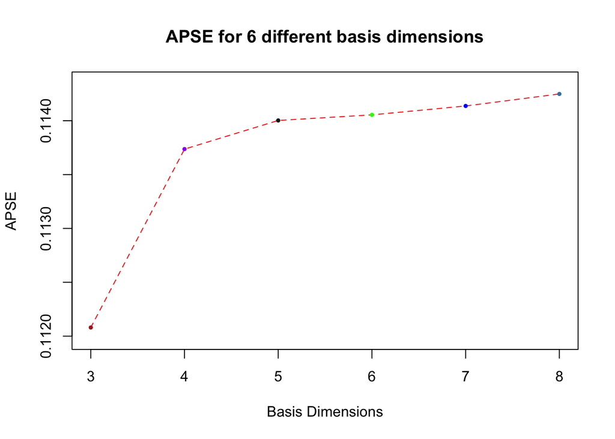

```r
ylim = extendrange(apses)
plot(complexity, apses, xlab = "Basis Dimensions",
     ylab="APSE", ylim=ylim,
     main="APSE for 6 different basis dimensions",
     type="n") # "n" suppresses the plot, add values later
lines(complexity, apses, lwd=1, col="red", lty=2)
points(complexity,apses, pch=19, cex=0.5,
       col=c("firebrick", "purple", "grey10", "green", "blue", "steelblue"))
```

From the graph, we could see that with a thin-plate spline, a 3-dimensional basis gives us the best APSE so far.

The above TPS model was fitted and tested under the assumption of no interaction between the predictors. We will model predictor interactions in the following code segment:

```r
getmuhat_tps_with_interaction <- function(sample, df) {
  fit <- gam(y~ s(x[,1], x[,2], x[,3], x[,4], bs="tp",k = df), data = sample)
  muhat <- function(x){predict(fit, x=x)}
  muhat
}
```

Now let’s plot the APSEs again:

```r
apses <- c()
complexity <- c(20, 21, 22, 23, 24, 25)
for (i in 20:25){
  model_apse <- apse(Ssamples, Tsamples, hyper_parameter = i, which_function = 4)
  apses <- c(apses, model_apse)
}
```

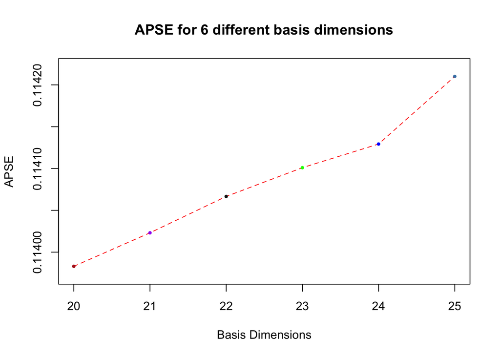

```r
ylim = extendrange(apses)
plot(complexity, apses, xlab = "Basis Dimensions",
     ylab="APSE", ylim=ylim,
     main="APSE for 6 different basis dimensions",
     type="n") # "n" suppresses the plot, add values later
lines(complexity, apses, lwd=1, col="red", lty=2)
points(complexity,apses, pch=19, cex=0.5,
       col=c("firebrick", "purple", "grey10", "green", "blue", "steelblue"))
```

The value of $k$ had to be increased up to minimum $20$ when switching from an additive to an interactive model, otherwise R would generate warning messages and automatically re-set $k$ to minimal required value.

We could see from the two APSE plots that an additive model where independence between the predictors is assumed, fited over a thin-place splien with $dim(basis) = 3$, gives us the current lowest APSE value at $apse \approx 0.112$, averaged over $100$ bootstrapped samples.

Finally, we will report the estimate of the prediction error based on GCV score of the tuned thin-place spline, fitted over the entire data set.:

```r
## since GCV scores are reported as a part of the model fit, we will use the full data set
x <- rbind(x_train_final_predictors, x_test_final_predictors)
y <- rbind(y_train_transformed_logged, y_test_transformed_logged)
fit <- gam(unlist(y)~s(x[,1],bs="tp",k=3) + s(x[,2], bs="tp",k=3) +
             s(x[,3],bs="tp",k=3) + s(x[,4], bs="tp",k=3))
GCVScore <- fit$gcv.ubre
GCVScore
```

```
##      GCV.Cp
## 0.009128537
```

**The final prediction error for an additive thin-plate spline with a 3-dimensional basis is approximately 0.009 based on GCV score.**

## Radom Forests:

Use random forests models on your data, report the importance of variables and your prediction error. If you use CV to estimate prediction error, use 5-fold.

Now let’s fit a random forest model on the dataset. The hyper parameter to be tuned is $mtry$, where $mtry$ is equal to the number of variables randomly checked at every internal node during the tree-building procedure. While it is true that both the number of trees and the number of variables affect the final prediction error, the estimated error converges for large enough number of trees. Hence in this report we will only be tuning the $mtry$ parameter and we will set $n.trees = 50$ for all different values of $mtry$.

A note on computational efficiency: throughout many trials prior to this final report draft, our group has experienced exponentially slow runtime as the number of training and testing samples increased. It is simply not a realistic task to average the APSE values over all 100 training and testing samples. Instead, we decided to lower the number down to 20. Since asymptotically random forest has a lower bound on estimated errors, even 20 samples should provide a good insight for parameter tuning.

```r
## Random Forests -- we're interested in mtry
getmuhat_rf_mtry <- function(sample, mtry){
  fit <- randomForest(x = sample$x, y = sample$y, ntree = 50,
               mtry = mtry, importance = TRUE, proximity = TRUE)
  muhat <- function(x){predict(fit, newdata = x, ntree = 50)}
  muhat
}
```

```r
apses <- c()
complexity <- c(1, 2, 3, 4, 5)
for (i in 1:5){
  model_apse <- apse(Ssamples[c(seq(1,20))], Tsamples[c(seq(1,20))],
                     hyper_parameter = i, which_function = 2)
  apses <- c(apses, model_apse)
}
```

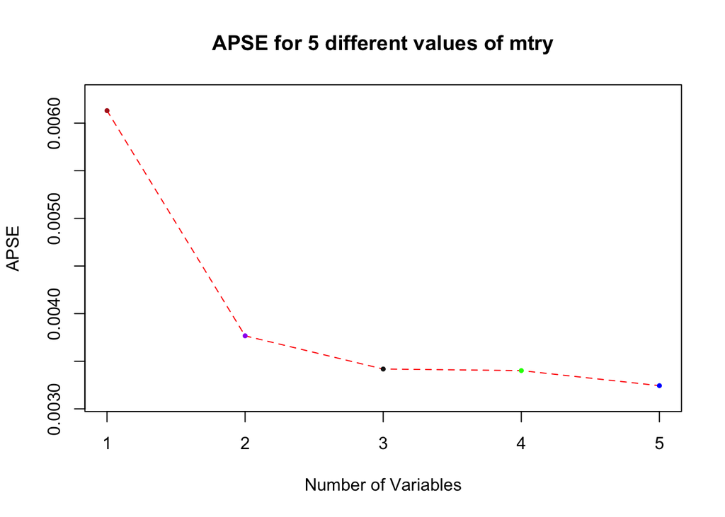

```r
ylim = extendrange(apses)
plot(complexity, apses, xlab = "Number of Variables",
     ylab="APSE", ylim=ylim,
     main="APSE for 5 different values of mtry",
     type="n") # "n" suppresses the plot, add values later
lines(complexity, apses, lwd=1, col="red", lty=2)
points(complexity,apses, pch=19, cex=0.5,
       col=c("firebrick", "purple", "grey10", "green", "blue", "steelblue"))
```

From the plots, we could see that a value of $mtry = 5$ at $ntree = 50$ gives us the lowest APSE so far. Set these parameters as our final model and get the following variable importance plot (normalized over the max value of all variable importance scores):

```r
x <- rbind(x_train_final_predictors, x_test_final_predictors)
y <- rbind(y_train_transformed_logged, y_test_transformed_logged)
model <- randomForest(x = x[,1:5], y = y[,1], ntree = 50,
                      mtry = 5, importance = TRUE, proximity = TRUE)
```

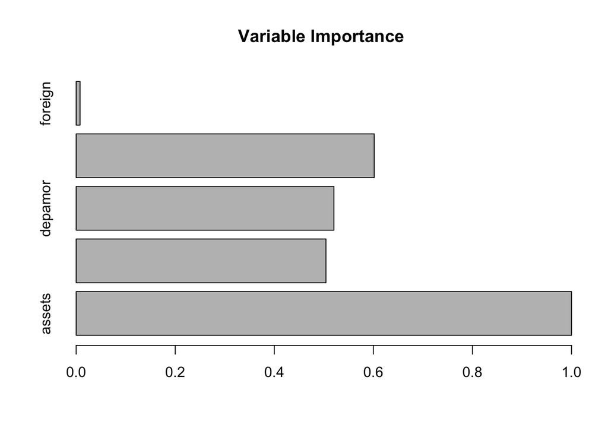

```r
barplot(model$importanceSD/max(model$importanceSD), main="Variable Importance", horiz=TRUE)
```

```r
model$importanceSD/max(model$importanceSD)
```

```
##      assets      debtnc     depamor      ncfdiv     foreign
## 1.000000000 0.504269262 0.520350241 0.601705251 0.007823292
```

Out-of-bag error usually provides a rough estimate of the true error. While it is not a reliable estimate, we could visualize how the true error is reduced over increasing number of iterations by plotting the out-of-bag error:

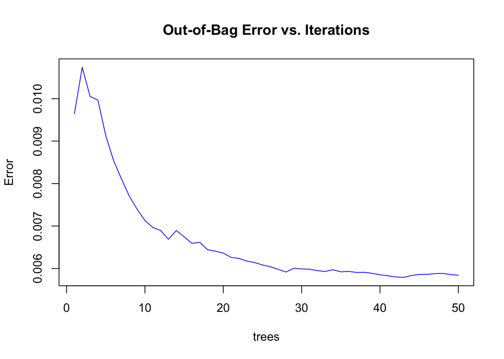

```r
plot(model, main = "Out-of-Bag Error vs. Iterations", col = 'blue')
```

To obtain an estimate of the prediction error, we could either use the out-of-bag error or the cross-validation error. Since it was discussed in class that the out-of-bag error tends to underestimate the true error, we shall use a 5-fold cross validation to estimate the total error.

```r
cverr <- 0

for (i in 1:5){
  train_x <- CVSets[[1]][[i]][,1:5]
  train_y <- CVSets[[1]][[i]][,6]
  test_x <- CVSets[[2]][[i]][,1:5]
  test_y <- CVSets[[2]][[i]][,6]
  model <- randomForest(x = train_x, y = train_y, ntree = 50,
               mtry = 5, importance = TRUE, proximity = TRUE)
  predicted_y <- predict(model, newdata = test_x, ntree = 50)
  cverr <- cverr + APSE_Formula(test_y, predicted_y)[1]
}
cverr <- cverr / 5
```

From the 5-fold cross-validated result, we have an estimated APSE of:

```r
cverr
```

```
## [1] 0.005918807
```

## Boosting:

For boosted trees, we need to define more customized $getmuhat$ functions:

```r
ave_y_mu_sq_for_boost <- function(sample, predfun){
  mean(abs(sample$y - predfun(sample))^2)
}

getmuhat_boost <- function(sample, depth){
  fit <- gbm(y ~ x[,1] + x[,2] + x[,3] + x[,4] + x[,5],
             data = sample, n.trees = 50, shrinkage = 0.01,
             interaction.depth = depth, distribution = "gaussian")
  print(fit)
  muhat <- function(input){
    predict(fit, input, n.trees = 50)
    }
  muhat
}
```

We are interested in two factors affecting the APSE: **interaction depth** of the boosted trees and the **shrinkage factor**. We will tune these two hyper parameters separately:

```r
apses <- c()
complexity <- c(seq(1, 20))
for (i in 1:20){
  model_apse <- apse(Ssamples, Tsamples, hyper_parameter = i, which_function = 3)
  apses <- c(apses, model_apse)
}
```

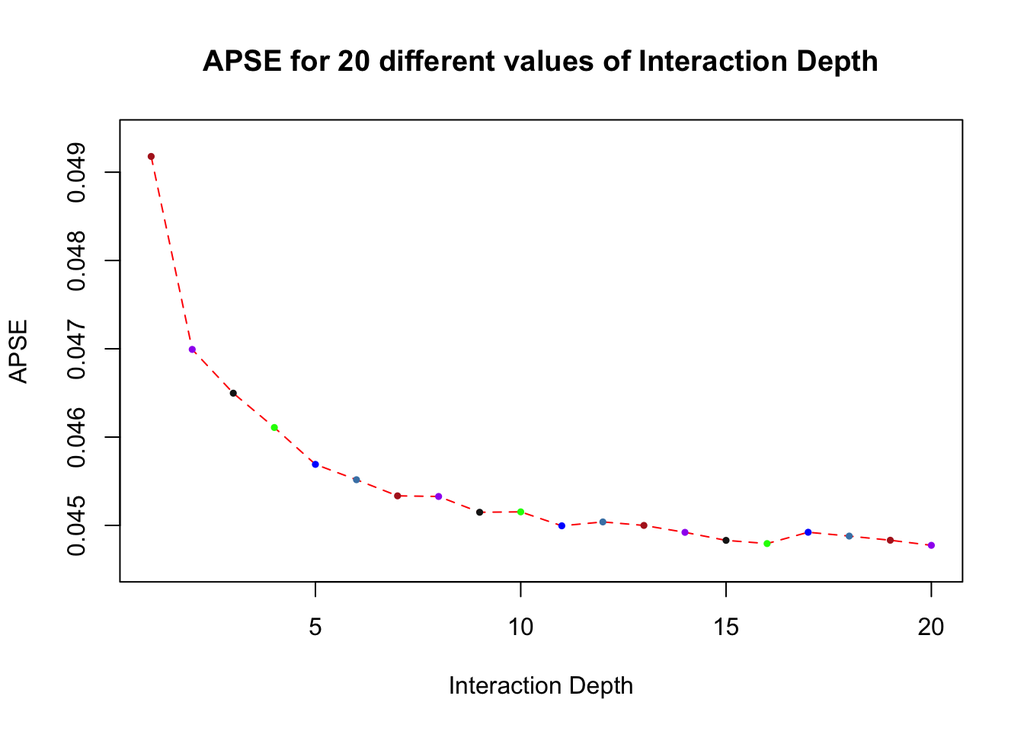

```r
ylim = extendrange(apses)
plot(complexity, apses, xlab = "Interaction Depth",
     ylab="APSE", ylim=ylim,
     main="APSE for 20 different values of Interaction Depth",
     type="n") # "n" suppresses the plot, add values later
lines(complexity, apses, lwd=1, col="red", lty=2)
points(complexity,apses, pch=19, cex=0.5,
       col=c("firebrick", "purple", "grey10", "green", "blue", "steelblue"))
```

From the plot, could see that the APSE decreases drastically then slows down and stabilizes after $depth \geq 15$. Hence we will move on to tune the $shrinkage$ parameter and set $interactin.depth$ to a fixed value of $20$.

```r
getmuhat_boost_lambda <- function(sample, lambda){
  fit <- gbm(y ~ x[,1] + x[,2] + x[,3] + x[,4] + x[,5],
             data = sample, n.trees = 50, shrinkage = lambda,
             interaction.depth = 20, distribution = "gaussian")
  print(fit)
  muhat <- function(input){
    predict(fit, input, n.trees = 50)
    }
  muhat
}

apses <- c()
complexity <- c(seq(0, 0.2, 0.005))
for (i in complexity){
  model_apse <- apse(Ssamples, Tsamples, hyper_parameter = i, which_function = 5)
  apses <- c(apses, model_apse)
}
```

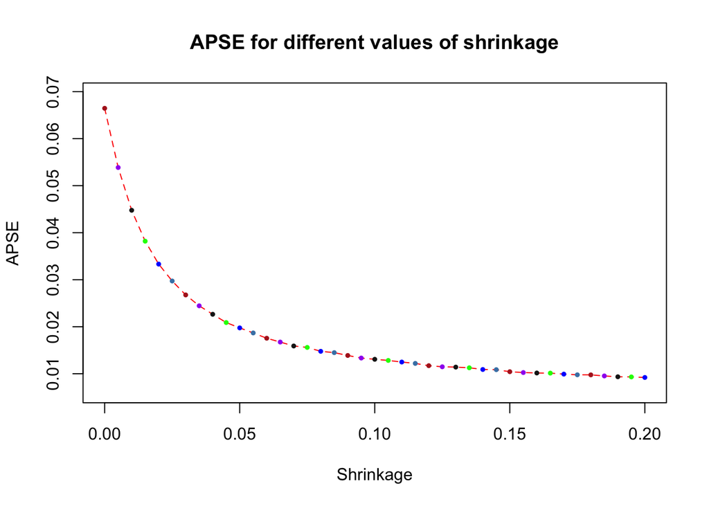

```r
ylim = extendrange(apses)
plot(complexity, apses, xlab = "Shrinkage",
     ylab="APSE", ylim=ylim,
     main="APSE for different values of shrinkage",
     type="n") # "n" suppresses the plot, add values later
lines(complexity, apses, lwd=1, col="red", lty=2)
points(complexity,apses, pch=19, cex=0.5,
       col=c("firebrick", "purple", "grey10", "green", "blue", "steelblue"))
```

Our finalized hyper parameters for the boosted tree model is $interaction.depth = 20$ and $shrinkage = 0.20$, with $n.trees = 50$.

We can obtain a plot of the variable importance normalized over the max importance score in the following code segment:

```r
x <- rbind(x_train_final_predictors, x_test_final_predictors)
y <- rbind(y_train_transformed_logged, y_test_transformed_logged)
data <- cbind(x, y)
model <- gbm(V1~., n.trees = 50, data = data,
             shrinkage = 0.20, interaction.depth = 20, distribution = "gaussian")
```

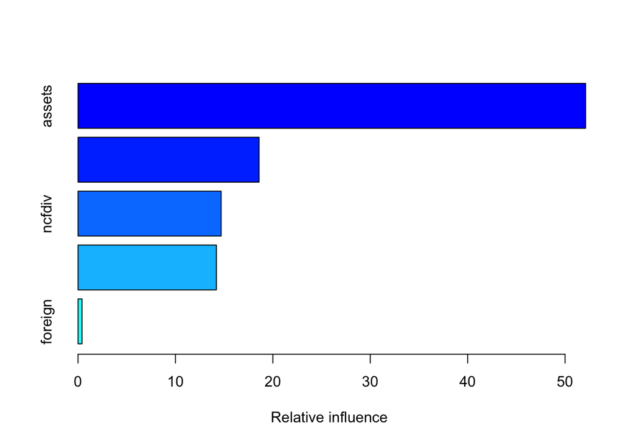

```r
summary(model)
```

We can also visualize how the training error decreases over each iteration:

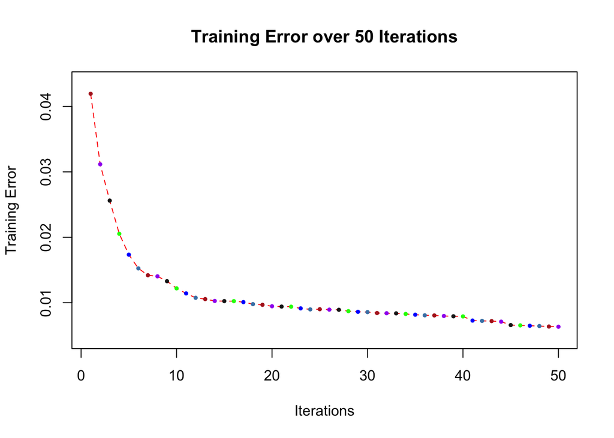

```r
ylim = extendrange(model$train.error)
plot(c(seq(1, model$n.trees)), model$train.error, xlab = "Iterations",
     ylab="Training Error", ylim=ylim,
     main="Training Error over 50 Iterations",
     type="n") # "n" suppresses the plot, add values later
lines(c(seq(1, model$n.trees)), model$train.error, lwd=1, col="red", lty=2)
points(c(seq(1, model$n.trees)),model$train.error, pch=19, cex=0.5,
       col=c("firebrick", "purple", "grey10", "green", "blue", "steelblue"))
```

Now let’s perform 5-fold cross validation to obtain an estimate of the prediction error:

```r
cverr <- 0
for (i in 1:5){
  training_data <- CVSets[[1]][[i]]
  testing_data <- CVSets[[2]][[i]]
  model <- gbm(V1~., n.trees = 50, data = training_data,
               shrinkage = 0.20, interaction.depth = 20, distribution = "gaussian")
  predicted_y <- predict(model, newdata = testing_data, n.trees = 50)
  cverr <- cverr + APSE_Formula(testing_data[,6], predicted_y)[1]
}
cverr <- cverr / 5
```

From the 5-fold cross-validated result, we have an estimated APSE of:

```r
cverr
```

```
## [1] 0.01687731
```

## Conclusions in the context of the problem:

Based on our findings, we conclude that assets, non-current debt, depreciation, amortization & accretion, and payment of dividends & other cash distributions are the most important factors when modelling the retained earnings of a company. While a company’s country of origin (domestic vs. foreign) improves the accuracy of the predictions, the benefits are only marginal. Hence the most efficient and practical way of modelling retained earnings is to use the above-mentioned four factors. As an extension of our results, we can further make the inference that a company’s retained earnings is significantly affected by its cash managent and its asset-liability ratios. Therefore even in the absence of one or two of the four important predictors, a decent model could still be obtained as long as some form of data on assets and debt are available.

In terms of application, the models we derived can be used by a variety of groups. For business analysts, predicted retained earnings can be used to conduct market analysis. For sales and marketing executives, our models can be used to compile pitchbooks for new investment packages. Last but not least, hedge fund managers can use our model to make seasonal or annual adjustments to their clients’ portfolios. While it took a lot of effort to pre-process the data and tune the parameters, our finalized models are all very concise and easy to run, regardless of the users’ background knowledge in statistics or computer science.

## Future work:

### Aspects we wish to have done better:

1. More sophisticated variable selection methods: due to time constraints and the sheer number of potential predictors, we were unable to investigate all potential interactions between the predictors. If we had more time, we would try more complicated variable screening techniques.
2. Imputation: missing value imputation is a topic that has been researched in-depth by a lot of scholars, and we wish we had more time to try out different imputation packages in R such as $MICE$ so that we could retain more rows from the original data set.

### Weakness of the current methods:

1. Runtime of random forests: while random forests give the lowest APSE out of all models we constructed and tuned, it does not scale well with increased number of observations and predictors. This inefficiency cripples the strength of the model by a lot, as in real life analysts would deal with much larger databases and many more predictors. A quick way to improve the runtime is to concurrently execute $m$ threads where $m$ is the number of iterations, since each iteration builds a tree and therefore can be executed independently. We would have tried concurrent threads on random forest if we had more time for this project.

### Data Collection:

1. We were interested in obtaining more back-dated data on the companies and analyze how serially correlated data could hurt or help our current models, as well as how to construct a mixed model that contains categorical predictors, continuous predictors, continuous time-series predictors, and categorical time-series predictors. All of this requires scraping more data off the internet, which we did not have the time for.
2. Additionally, as we had seen with this project, raw data in real life is usually a mess to work with and often requires a lot of pre-processing, imputation, cleaning, and scaling. Given more time, we would have contunued to improve the quality of our data set as well.

## Contribution:

- Abhi: Data cleaning and pre-processing
- Alvin: Variable screening and selection
- Rosie: Model selection and parameter tuning, report compilation

## Appendix:

### A Note on Reproductibility:

For faster PDF compilation time, we disabled some code block executions and directly used cached results, namely the python code blocks in the data processing section and the R code for concurrent threads in the variable selection section. To fully reproduce the results, please go through all code blocks in the markdown file and reset $eval$ to $TRUE$ when applicable.